# SearchLove Game

## A Game of Ads

Start with some imports.

Scipy for some statistics, numpy for random number generation and pandas for the data frames

```python
import scipy.stats as stats
import numpy as np
import pandas as pd
```

The ClicksGame class implements all the state for the game

```python
class ClicksGame:
    # alpha and beta determine the distribution from which
    # new click through rates are drawn.
    # alpha=5, beta=100 will give a very narrow distribution
    # with little variance in click through rates.
    # alpha=2, beta=20 is a little fatter
    alpha = 2
    beta = 20

    # weeklyimpressions is the number of trials per week in total
    # The trials are distributed between the ads according to the
    # rotation method
    weeklyimpressions = 1000

    # The starting state - no ads.
    state = {}

    def __init__(self, rotation='even', epsilon=0.1):
        if rotation == 'even':
            self.rotation = self.evenAllocation
        elif rotation == 'optimise':
            self.rotation = self.epsilonGreedy
            self.epsilon = epsilon
        self.state = {'active_ads': {},
                      'paused_ads': {},
                      'n_ads': 0,
                      'turns': 0,
                     }
    def take_turn(self):
        self.rotation()

    def n_ads(self):
        return(self.state['n_ads'])

    def n_active_ads(self):
        return(len(self.state['active_ads']))


    def addAdvert(self):
        # Adds an advert.
        # First randomly generate the click through rate
        ctr = np.random.beta(self.alpha,self.beta,1)[0]
        ad = {'impressions':0,
              'clicks':0,
              'trueCtr': ctr
             }
        n_ads = self.state['n_ads']
        self.state['active_ads'][n_ads+1] = ad
        self.state['n_ads'] += 1

    def pauseAdvert(self,i):
        # Pause advert with id i.
        if i in self.state['active_ads']:
            ad = self.state['active_ads'].pop(i)
            self.state['paused_ads'][i] = ad

    def total_clicks(self):
        clicks = 0
        for i in self.state['active_ads']:
            clicks += self.state['active_ads'][i]['clicks']
        for i in self.state['paused_ads']:
            clicks += self.state['paused_ads'][i]['clicks']
        return(clicks)

    def evenAllocation(self):
        # Randomly allocate impressions between all active adverts
        self.state['turns'] += 1
        if self.state['active_ads']:
            n_active = len(self.state['active_ads'])
            impressions = np.random.multinomial(self.weeklyimpressions,
                                                [1/n_active]*n_active,
                                                size=1
                                                )
            impressions = np.ndarray.tolist(impressions)[0]
            for adix in self.state['active_ads']:
                ad = self.state['active_ads'][adix]
                imps = impressions.pop()
                clicks = np.random.binomial(imps, ad['trueCtr'], 1)[0]
                self.state['active_ads'][adix]['impressions'] += imps
                self.state['active_ads'][adix]['clicks'] += clicks

    def epsilonGreedy(self):
        # Epsilon greedy bandit allocation
        # Allocated self.epsilon percent of impressions randomly
        # The remaining 1-self.epsilon percent are given to the ad
        # with the best observed ctr.
        #
        # N.B. This allocation method takes a lot longer to run than
        # even allocation. This will always be the case I think but this
        # isn't to say that the below code can't be made much quicker.
        self.state['turns'] += 1
        if self.state['active_ads']:
            for i in range(self.weeklyimpressions):
                if np.random.uniform(0,1,1)[0] < self.epsilon:
                    #explore
                    adix = np.random.choice(list(self.state['active_ads'].keys()),1)[0]
                    self.state['active_ads'][adix]['impressions'] += 1
                    click = np.random.uniform(0,1,1)[0] < self.state['active_ads'][adix]['trueCtr']
                    self.state['active_ads'][adix]['clicks'] += click
                else:
                    #exploit
                    s = self.state
                    ctrs = [s['active_ads'][x]['clicks']/s['active_ads'][x]['impressions']
                            if s['active_ads'][x]['impressions'] is not 0 else 0
                            for x in s['active_ads']]
                    maxctr = max(ctrs)
                    for adix in s['active_ads']:
                        if s['active_ads'][adix]['impressions'] == 0 or s['active_ads'][adix]['clicks']/s['active_ads'][adix]['impressions'] < maxctr:
                            pass
                        else:
                            self.state['active_ads'][adix]['impressions'] += 1
                            click = np.random.uniform(0,1,1)[0] < self.state['active_ads'][adix]['trueCtr']
                            self.state['active_ads'][adix]['clicks'] += click
```

Quick demonstration game where we add two adverts and then run a week:

```python
c = ClicksGame(rotation='optimise')
c.addAdvert()
c.addAdvert()
c.take_turn()
c.state
```

```
{'active_ads': {1: {'clicks': 88,
   'impressions': 779,
   'trueCtr': 0.10795954112418148},
  2: {'clicks': 15, 'impressions': 214, 'trueCtr': 0.088679615145492843}},
 'n_ads': 2,
 'paused_ads': {},
 'turns': 1}
```

Now start to define some different ad test strategies.

The simplest is to add two adverts and then do nothing.

```python
def doNothing(c):
    while c.n_active_ads() < 2:
        c.addAdvert()
    c.take_turn()
```

```python
c = ClicksGame()
doNothing(c)
doNothing(c)
c.state
```

```
{'active_ads': {1: {'clicks': 82,
   'impressions': 1011,
   'trueCtr': 0.083759471000148675},
  2: {'clicks': 82, 'impressions': 989, 'trueCtr': 0.072707733964301746}},
 'n_ads': 2,
 'paused_ads': {},
 'turns': 2}
```

A strategy which is impossible in real life but which is possible in the game is to cheat by looking at the true click through rate and picking the advert that is best.

It is useful to have this strategy as a comparison; any other strategy that does nearly as well as cheating must be pretty good.

```python
def cheat(c):
    while c.n_active_ads() < 2:
        c.addAdvert()
    c.take_turn()
    s = c.state
    ctrs = [s['active_ads'][x]['trueCtr'] for x in s['active_ads']]
    maxctr = max(ctrs)
    to_pause = []
    for i in s['active_ads']:
        if s['active_ads'][i]['trueCtr'] < maxctr:
            to_pause.append(i)
    for i in to_pause:
        c.pauseAdvert(i)
```

```python
c = ClicksGame()
while c.state['turns'] < 5:
    cheat(c)

c.state
```

```
{'active_ads': {5: {'clicks': 204,
   'impressions': 1004,
   'trueCtr': 0.18339487222248058}},
 'n_ads': 6,
 'paused_ads': {1: {'clicks': 21,
   'impressions': 504,
   'trueCtr': 0.042531824031978249},
  2: {'clicks': 118, 'impressions': 1484, 'trueCtr': 0.07558811885068413},
  3: {'clicks': 23, 'impressions': 519, 'trueCtr': 0.052936233078316852},
  4: {'clicks': 102, 'impressions': 982, 'trueCtr': 0.080658421522488699},
  6: {'clicks': 40, 'impressions': 507, 'trueCtr': 0.092294268564702811}},
 'turns': 5}
```

Another strawman strategy is to pick adverts to pause at random.

```python
def random(c):
    while c.n_active_ads() < 2:
        c.addAdvert()
    c.take_turn()
    s = c.state
    ads = list(s['active_ads'].keys())
    ad_to_pause = np.random.choice(ads,1)[0]
    c.pauseAdvert(ad_to_pause)
```

```python
s = ClicksGame()
while s.state['turns'] < 5:
    random(s)

s.state
```

```
{'active_ads': {6: {'clicks': 111,
   'impressions': 501,
   'trueCtr': 0.1914446524341035}},
 'n_ads': 6,
 'paused_ads': {1: {'clicks': 154,
   'impressions': 2439,
   'trueCtr': 0.065348580171771239},
  2: {'clicks': 22, 'impressions': 497, 'trueCtr': 0.045655369615622714},
  3: {'clicks': 59, 'impressions': 526, 'trueCtr': 0.099652566043553659},
  4: {'clicks': 36, 'impressions': 528, 'trueCtr': 0.069917814742279122},
  5: {'clicks': 177, 'impressions': 509, 'trueCtr': 0.33433599714983936}},
 'turns': 5}
```

A more common strategy is to do nothing until a chi-squared test has a p-value below a certain threshold.

The pick the ad with the best observed ctr.

```python
def chi2(pvalue,c):
    while c.n_active_ads() < 2:
        c.addAdvert()
    c.take_turn()
    clicks = c.total_clicks()
    if clicks > 0:
        obs = []
        for i in c.state['active_ads']:
            ad = c.state['active_ads'][i]
            obs.append([ad['clicks'], ad['impressions']-ad['clicks']])
        p = stats.chi2_contingency(obs)[1]
        if p < pvalue:
            s = c.state
            ctrs = [s['active_ads'][x]['clicks']/s['active_ads'][x]['impressions'] for x in s['active_ads']]
            maxctr = max(ctrs)
            to_pause = []
            for i in s['active_ads']:
                ad = s['active_ads'][i]
                obs_ctr = ad['clicks']/ad['impressions']
                if obs_ctr < maxctr:
                    to_pause.append(i)
            for i in to_pause:
                c.pauseAdvert(i)
```

```python
s = ClicksGame()
while s.state['turns'] < 10:
    chi2(0.1,s)

s.state
```

```
{'active_ads': {2: {'clicks': 824,
   'impressions': 5006,
   'trueCtr': 0.16606703563697534},
  5: {'clicks': 590, 'impressions': 3490, 'trueCtr': 0.16131558839301935}},
 'n_ads': 5,
 'paused_ads': {1: {'clicks': 17,
   'impressions': 507,
   'trueCtr': 0.037307833755827212},
  3: {'clicks': 19, 'impressions': 520, 'trueCtr': 0.029859760520460937},
  4: {'clicks': 37, 'impressions': 477, 'trueCtr': 0.080969023930524034}},
 'turns': 10}
```

The G Test is very similar to chi-squared. Some people consider it more appropriate for this kind of problem

```python
def g_test(pvalue,c):
    while c.n_active_ads() < 2:
        c.addAdvert()
    c.take_turn()
    clicks = c.total_clicks()
    if clicks > 0:
        obs = []
        for i in c.state['active_ads']:
            ad = c.state['active_ads'][i]
            obs.append([ad['clicks'], ad['impressions']-ad['clicks']])
        p = stats.chi2_contingency(obs,lambda_="log-likelihood")[1]
        if p < pvalue:
            s = c.state
            ctrs = [s['active_ads'][x]['clicks']/s['active_ads'][x]['impressions'] for x in s['active_ads']]
            maxctr = max(ctrs)
            to_pause = []
            for i in s['active_ads']:
                ad = s['active_ads'][i]
                obs_ctr = ad['clicks']/ad['impressions']
                if obs_ctr < maxctr:
                    to_pause.append(i)
            for i in to_pause:
                c.pauseAdvert(i)
```

An easy thing to do is to just pick the best advert and pause all the others.

```python
def pick_best(n_adverts,c):
    while c.n_active_ads() < n_adverts:
        c.addAdvert()
    c.take_turn()
    s = c.state
    ctrs = [s['active_ads'][x]['clicks']/s['active_ads'][x]['impressions'] if s['active_ads'][x]['impressions'] is not 0 else 0 for x in s['active_ads']]
    maxctr = max(ctrs)
    to_pause = []
    for i in s['active_ads']:
        ad = s['active_ads'][i]
        obs_ctr = ad['clicks']/ad['impressions'] if ad['impressions'] is not 0 else 0
        if obs_ctr < maxctr:
            to_pause.append(i)
    for i in to_pause:
        c.pauseAdvert(i)
```

The tqdm package provides nice progress bars.

```python
from tqdm import tnrange,tqdm_notebook
```

`playGame` runs a strategy for a specified number of turns using even ad rotation

```python
def playGame(strategy,turns):
    s = ClicksGame()
    while s.state['turns'] < turns:
        strategy(s)
    return(s.total_clicks())
```

```python
games = [
    ('nothing',doNothing),
    ('cheat', cheat),
    ('random', random),
    ('chi2_0.01', lambda s: chi2(0.01,s)),
    ('chi2_0.05', lambda s: chi2(0.05,s)),
    ('chi2_0.10', lambda s: chi2(0.1,s)),
    ('chi2_0.20', lambda s: chi2(0.2,s)),
    ('gtest_0.01', lambda s: g_test(0.01,s)),
    ('gtest_0.05', lambda s: g_test(0.05,s)),
    ('gtest_0.10', lambda s: g_test(0.1,s)),
    ('gtest_0.20', lambda s: g_test(0.2,s)),
    ('pick_best', lambda s: pick_best(2,s))
]
```

Play all games

```python
import os

if os.path.isfile("rotate1.csv"):
    r = pd.read_csv("rotate1.csv",index_col=0)
    r["row"] = r.index % 1000
    results = r.pivot(index="row",columns="variable",values="value")
else:
    results = {}
    for (label,game) in tqdm_notebook(games,desc="Strategy"):
        res = []
        for i in tqdm_notebook(range(1000), desc=label, leave=False):
            c = playGame(game,52)
            res.append(c)
        results[label] = res
    results = pd.DataFrame(results)
```

```python
x = pd.DataFrame(pd.DataFrame.mean(results))
x.columns = ['Clicks']
x.index.name = "Strategy"
x.reset_index(inplace=True)

x
```

|  | Strategy | Clicks |
| --- | --- | --- |
| 0 | cheat | 8422.771 |
| 1 | chi2_0.01 | 7699.615 |
| 2 | chi2_0.05 | 7896.281 |
| 3 | chi2_0.10 | 8049.524 |
| 4 | chi2_0.20 | 8199.191 |
| 5 | gtest_0.01 | 7655.258 |
| 6 | gtest_0.05 | 7950.070 |
| 7 | gtest_0.10 | 7967.160 |
| 8 | gtest_0.20 | 8131.526 |
| 9 | nothing | 4738.289 |
| 10 | pick_best | 8287.084 |
| 11 | random | 4723.216 |

`Cheat` performs the best (obviously). Out of all the other strategies, the general trend is that higher p-values perform better and best of all is to just pick the ad with the highest observed ctr.

```python
import matplotlib as mpl
import matplotlib.pyplot as plt
import seaborn as sns
```

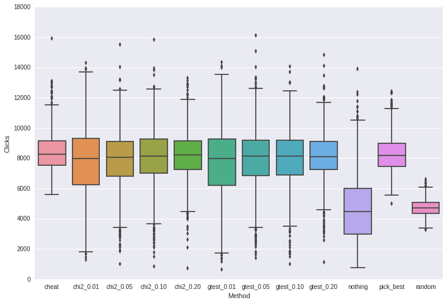

```python
df = pd.melt(results)
if not os.path.isfile("rotate1.csv"):
    df.to_csv("rotate1.csv")
plt.figure(figsize=(24,16))
p = sns.boxplot(x="Strategy", y="value", data=df)
p.set(xlabel="Method", ylabel="Clicks")
sns.plt.show()
```

Does using the epsilon-greedy algorithm to optimise ad rotation make a difference?

*(This code takes a while to run - nearly 3 hours on my machine).*

```python
def playEGGame(strategy,turns):
    s = ClicksGame(rotation='optimise')
    while s.state['turns'] < turns:
        strategy(s)
    return(s.total_clicks())

if os.path.isfile("bandit1.csv"):
    r = pd.read_csv("bandit1.csv",index_col=0)
    r["row"] = r.index % 1000
    bandit_results = r.pivot(index="row",columns="variable",values="value")
else:
    bandit_results = {}
    for (label,game) in tqdm_notebook(games,desc="Strategy"):
        res = []
        for i in tqdm_notebook(range(1000), desc=label, leave=False):
            c = playEGGame(game,52)
            res.append(c)
        bandit_results[label] = res
    bandit_results = pd.DataFrame(bandit_results)
```

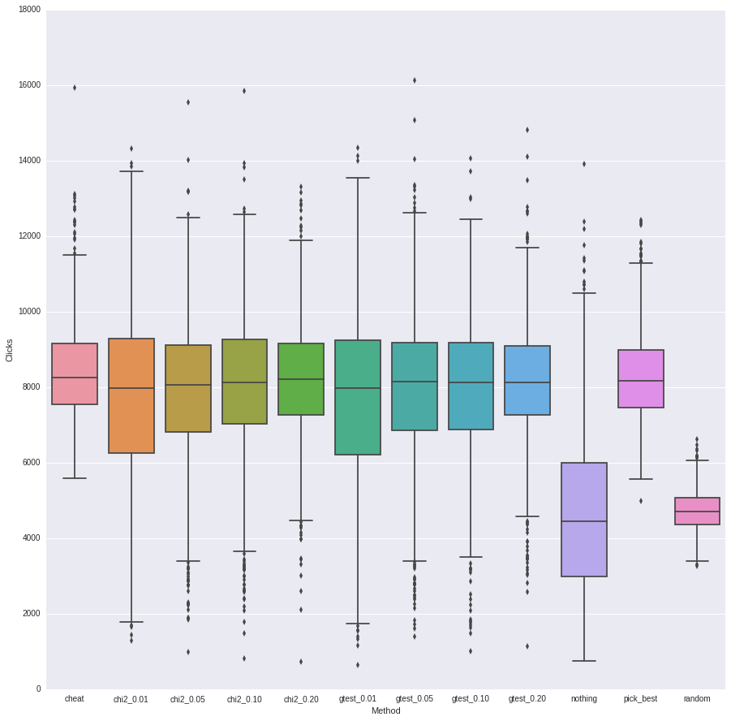

```python
bandit_df = pd.melt(bandit_results)
if not os.path.isfile("bandit1.csv"):
    bandit_df.to_csv("bandit1.csv")
plt.figure(figsize=(15,15))
p = sns.boxplot(x="Strategy", y="value", data=df)
p.set(xlabel="Method", ylabel="Clicks")
sns.plt.show()
```

```python
b = pd.DataFrame(pd.DataFrame.mean(bandit_results))
b.columns = ['Bandit']
b.index.name = "Strategy"
b.reset_index(inplace=True)
e = pd.DataFrame(pd.DataFrame.mean(results))
e.columns = ['Even']
e.index.name = "Strategy"
e.reset_index(inplace=True)

merged = pd.merge(b,e,on="Strategy")
merged['Difference'] = merged['Bandit'] - merged['Even']
merged['Percentage'] = merged['Bandit']/merged['Even'] - 1
merged
```

|  | Strategy | Bandit | Even | Difference | Percentage |
| --- | --- | --- | --- | --- | --- |
| 0 | cheat | 11777.088 | 8422.771 | 3354.317 | 0.398244 |
| 1 | chi2_0.01 | 7786.134 | 7699.615 | 86.519 | 0.011237 |
| 2 | chi2_0.05 | 8574.060 | 7896.281 | 677.779 | 0.085835 |
| 3 | chi2_0.10 | 8734.480 | 8049.524 | 684.956 | 0.085093 |
| 4 | chi2_0.20 | 9493.828 | 8199.191 | 1294.637 | 0.157898 |
| 5 | gtest_0.01 | 7958.364 | 7655.258 | 303.106 | 0.039594 |
| 6 | gtest_0.05 | 8579.690 | 7950.070 | 629.620 | 0.079197 |
| 7 | gtest_0.10 | 8975.440 | 7967.160 | 1008.280 | 0.126555 |
| 8 | gtest_0.20 | 9536.533 | 8131.526 | 1405.007 | 0.172785 |
| 9 | nothing | 6234.972 | 4738.289 | 1496.683 | 0.315870 |
| 10 | pick_best | 11487.823 | 8287.084 | 3200.739 | 0.386232 |
| 11 | random | 5904.835 | 4723.216 | 1181.619 | 0.250173 |

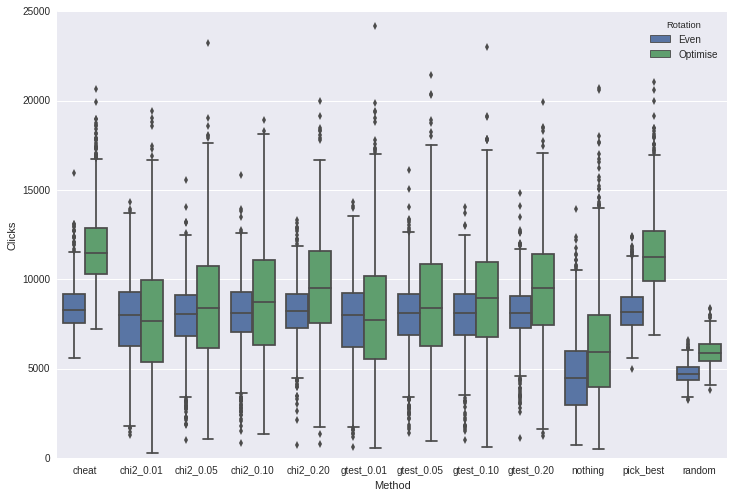

```python
df['Rotation'] = 'Even'
bandit_df['Rotation'] = 'Optimise'
bandit_df.rename(columns={"variable":"Strategy"}, inplace=True)

plt.figure(figsize=(12,8))
p = sns.boxplot(x="Strategy", y="value", hue="Rotation", data=pd.concat([df, bandit_df],ignore_index=True))
p.set(xlabel="Method", ylabel="Clicks")
sns.plt.show()
```

```python
n_ads = [("02", lambda s: pick_best(2, s)),
         ("03", lambda s: pick_best(3, s)),
         ("04", lambda s: pick_best(4, s)),
         ("05", lambda s: pick_best(5, s)),
         ("06", lambda s: pick_best(6, s)),
         ("07", lambda s: pick_best(7, s)),
         ("08", lambda s: pick_best(8, s)),
         ("09", lambda s: pick_best(9, s)),
         ("10", lambda s: pick_best(10, s))
        ]
n_ads.append(("cheat",cheat))

if os.path.isfile("nads1.csv"):
    r = pd.read_csv("nads1.csv",index_col=0)
    r["row"] = r.index % 1000
    n_ads_results = r.pivot(index="row",columns="variable",values="value")
else:
    n_ads_results = {}
    for (label,game) in tqdm_notebook(n_ads,desc="Strategy"):
        res = []
        for i in tqdm_notebook(range(1000), desc=label, leave=False):
            c = playGame(game,52)
            res.append(c)
        n_ads_results[label] = res
    n_ads_results = pd.DataFrame(n_ads_results)
```

```python
x = pd.DataFrame(pd.DataFrame.mean(n_ads_results))
x.columns = ['Clicks']
x.index.name = "Strategy/No. of ads"
x.reset_index(inplace=True)

x
```

|  | Strategy/No. of ads | Clicks |
| --- | --- | --- |
| 0 | 02 | 8328.438 |
| 1 | 03 | 7555.274 |
| 2 | 04 | 7087.282 |
| 3 | 05 | 6681.802 |
| 4 | 06 | 6392.498 |
| 5 | 07 | 6217.475 |
| 6 | 08 | 6043.088 |
| 7 | 09 | 5900.112 |
| 8 | 10 | 5802.490 |
| 9 | cheat | 8361.216 |

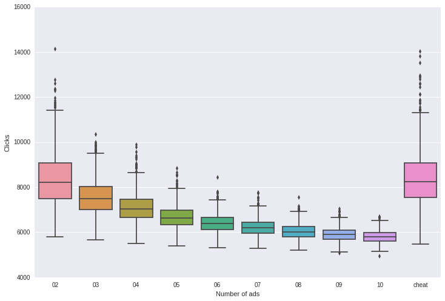

```python
n_ads_df = pd.melt(n_ads_results)
if not os.path.isfile("nads1.csv"):
    n_ads_df.to_csv("nads1.csv")
plt.figure(figsize=(12,8))
p = sns.boxplot(x="Strategy/No. of ads", y="value", data=n_ads_df)
p.set(xlabel="Number of ads", ylabel="Clicks")
sns.plt.show()
```

```python
if os.path.isfile("nads_bandit1.csv"):
    r = pd.read_csv("nads_bandit1.csv",index_col=0)
    r["row"] = r.index % 1000
    n_ads_bandit_results = r.pivot(index="row",columns="variable",values="value")
else:
    n_ads_bandit_results = {}
    for (label,game) in tqdm_notebook(n_ads,desc="Strategy"):
        res = []
        for i in tqdm_notebook(range(1000), desc=label, leave=False):
            c = playEGGame(game,52)
            res.append(c)
        n_ads_bandit_results[label] = res
    n_ads_bandit_results = pd.DataFrame(n_ads_bandit_results)
```

```python
x = pd.DataFrame(pd.DataFrame.mean(n_ads_bandit_results))
x.columns = ['Clicks']
x.index.name = "Strategy/No. of ads"
x.reset_index(inplace=True)

x
```

|  | Strategy/No. of ads | Clicks |
| --- | --- | --- |
| 0 | 02 | 11329.121 |
| 1 | 03 | 12573.173 |
| 2 | 04 | 13058.768 |
| 3 | 05 | 13423.703 |
| 4 | 06 | 13702.728 |
| 5 | 07 | 13895.402 |
| 6 | 08 | 14163.068 |
| 7 | 09 | 14142.196 |
| 8 | 10 | 14374.204 |
| 9 | cheat | 11720.622 |

With a bandit, adding more ads is very helpful. Throw shit against the wall and let the algorithm sort it out

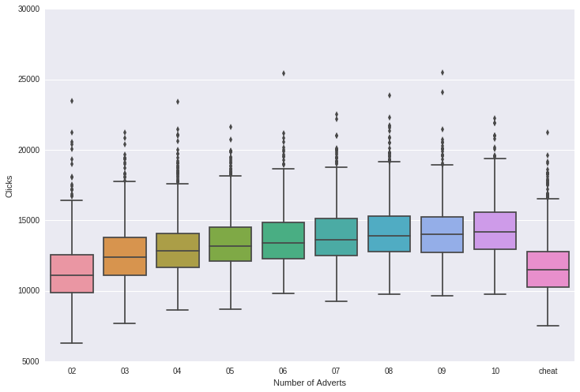

```python
n_ads_bandit_df = pd.melt(pd.DataFrame(n_ads_bandit_results))
if not os.path.isfile("nads_bandit1.csv"):
    n_ads_bandit_df.to_csv("nads_bandit1.csv")
plt.figure(figsize=(12,8))
p = sns.boxplot(x="Strategy/No. of ads", y="value", data=n_ads_bandit_df)
p.set(xlabel="Number of Adverts", ylabel="Clicks")
sns.plt.show()
```

```python
def play100ImpressionsGame(strategy,turns):
    s = ClicksGame()
    s.weeklyimpressions = 100
    while s.state['turns'] < turns:
        strategy(s)
    return(s.total_clicks())

results_100Impressions = {}

for (label,game) in tqdm_notebook(games,desc="Strategy"):
    res = []
    for i in tqdm_notebook(range(1000), desc=label, leave=False):
        c = play100ImpressionsGame(game,52)
        res.append(c)
    results_100Impressions[label] = res

results_100Impressions = pd.DataFrame(results_100Impressions)
```

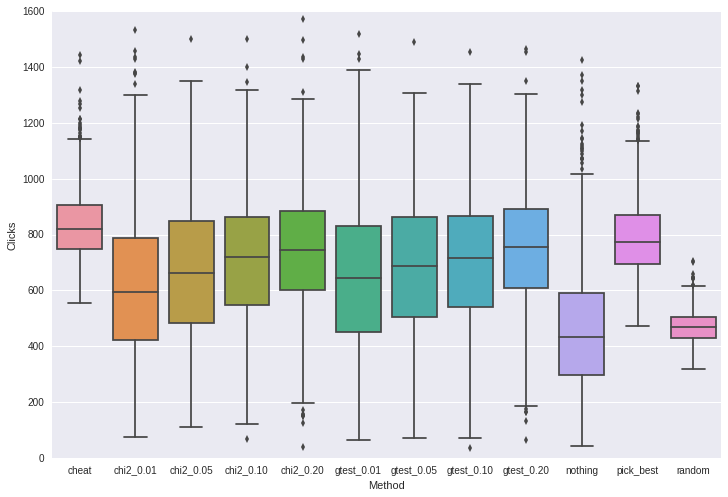

```python
df_100impressions = pd.melt(results_100Impressions)
plt.figure(figsize=(12,8))
p = sns.boxplot(x="variable", y="value", data=df_100impressions)
p.set(xlabel="Method", ylabel="Clicks")
sns.plt.show()
```

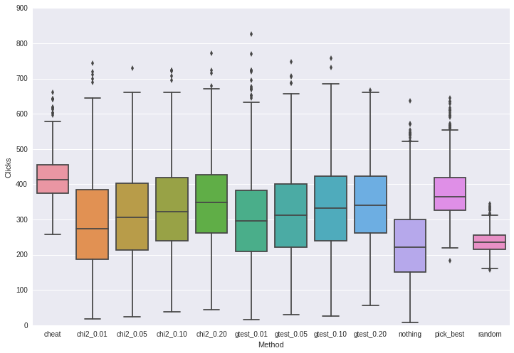

```python
def play50ImpressionsGame(strategy,turns):
    s = ClicksGame()
    s.weeklyimpressions = 50
    while s.state['turns'] < turns:
        strategy(s)
    return(s.total_clicks())

results_50Impressions = {}

for (label,game) in tqdm_notebook(games,desc="Strategy"):
    res = []
    for i in tqdm_notebook(range(1000), desc=label, leave=False):
        c = play50ImpressionsGame(game,52)
        res.append(c)
    results_50Impressions[label] = res

results_50Impressions = pd.DataFrame(results_50Impressions)

df_50impressions = pd.melt(results_50Impressions)
plt.figure(figsize=(12,8))
p = sns.boxplot(x="variable", y="value", data=df_50impressions)
p.set(xlabel="Method", ylabel="Clicks")
sns.plt.show()
```

# Maximise End Result

```python
def playEndResultGame(strategy,turns):
    s = ClicksGame()
    while s.state['turns'] < turns:
        strategy(s)
    ads = s.state['active_ads']
    best = max([ads[i]['trueCtr'] for i in ads])
    return(best,s.state["n_ads"])
```

```python
end_results = {}
end_results_n_ads = {}

for (label,game) in tqdm_notebook(games,desc="Strategy"):
    res = []
    n_ads = []
    for i in tqdm_notebook(range(1000), desc=label, leave=False):
        c,n = playEndResultGame(game,10)
        res.append(c)
        n_ads.append(n)
    end_results[label] = res
    end_results_n_ads[label] = n_ads
```

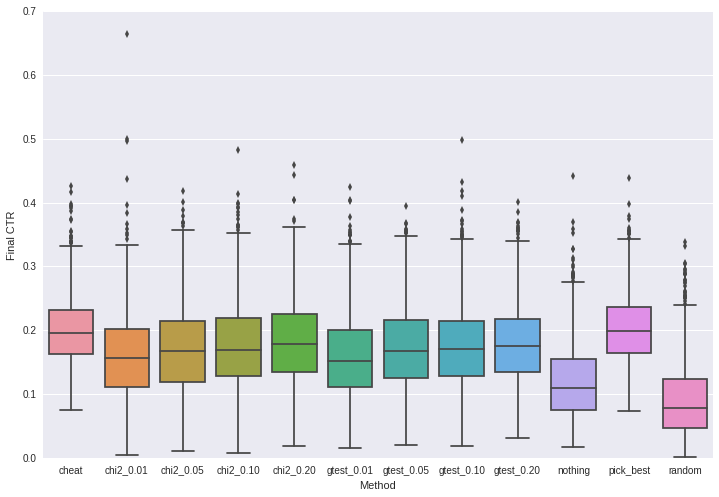

```python
end_results = pd.DataFrame(end_results)

df_end_results = pd.melt(end_results)
plt.figure(figsize=(12,8))
p = sns.boxplot(x="variable", y="value", data=df_end_results)
p.set(xlabel="Method", ylabel="Final CTR")
sns.plt.show()
```

```python
pd.DataFrame.mean(pd.DataFrame(end_results_n_ads))
```

```
cheat         11.000
chi2_0.01      6.221
chi2_0.05      7.041
chi2_0.10      7.604
chi2_0.20      8.212
gtest_0.01     6.188
gtest_0.05     6.901
gtest_0.10     7.514
gtest_0.20     8.219
nothing        2.000
pick_best     11.000
random        11.000
dtype: float64
```

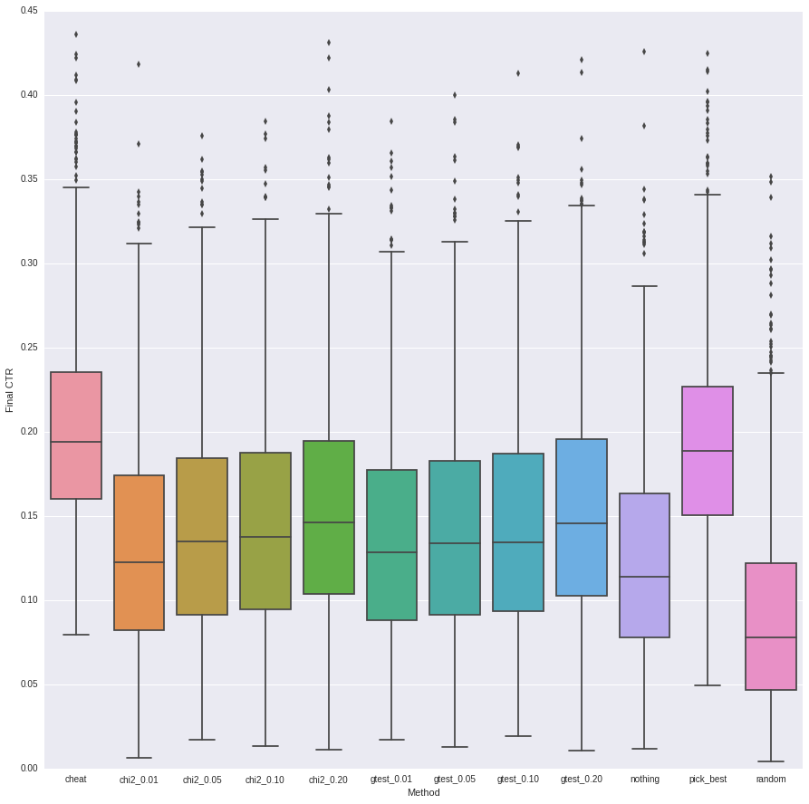

```python
def playEndResult100ImpressionsGame(strategy,turns):
    s = ClicksGame()
    s.weeklyimpressions = 100
    while s.state['turns'] < turns:
        strategy(s)
    ads = s.state['active_ads']
    best = max([ads[i]['trueCtr'] for i in ads])
    return(best)

end_results_100 = {}

for (label,game) in tqdm_notebook(games,desc="Strategy"):
    res = []
    for i in tqdm_notebook(range(1000), desc=label, leave=False):
        c = playEndResult100ImpressionsGame(game,10)
        res.append(c)
    end_results_100[label] = res

end_results_100 = pd.DataFrame(end_results_100)

df_end_results_100 = pd.melt(end_results_100)
plt.figure(figsize=(15,15))
p = sns.boxplot(x="variable", y="value", data=df_end_results_100)
p.set(xlabel="Method", ylabel="Final CTR")
sns.plt.show()
```

```
744/|/ 74%|| 744/1000 [01:39<00:34,  7.47it/s]
```

```
456/|/ 46%|| 456/1000 [00:29<00:35, 15.31it/s]
```

```
422/|/ 42%|| 422/1000 [00:17<00:23, 24.33it/s]
```

```
581/|/ 58%|| 581/1000 [01:58<01:25,  4.89it/s]
```

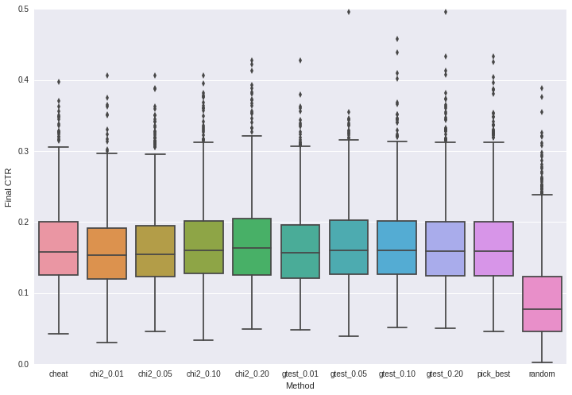

```python
def playRestrictedVariationsGame(strategy,ads):
    s = ClicksGame()
    while s.state['n_ads'] < ads:
        strategy(s)
    ads = s.state['active_ads']
    best = max([ads[i]['trueCtr'] for i in ads])
    return(best)

restricted_variations = {}

for (label,game) in tqdm_notebook(games[1:],desc="Strategy"):
    res = []
    for i in tqdm_notebook(range(1000), desc=label, leave=False):
        c = playRestrictedVariationsGame(game,5)
        res.append(c)
    restricted_variations[label] = res

restricted_variations = pd.DataFrame(restricted_variations)

restricted_variations_df = pd.melt(restricted_variations)
plt.figure(figsize=(12,8))
p = sns.boxplot(x="variable", y="value", data=restricted_variations_df)
p.set(xlabel="Method", ylabel="Final CTR")
sns.plt.show()
```

```
805/|/ 80%|| 805/1000 [7:03:20<1:42:33, 31.55s/it]
```

```
931/|/ 93%|| 931/1000 [00:56<00:04, 16.35it/s]
```

```
669/|/ 67%|| 669/1000 [00:17<00:08, 37.30it/s]
```

```
836/|/ 84%|| 836/1000 [01:14<00:14, 11.24it/s]
```

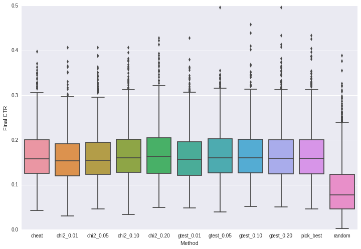

```python
def playRestrictedVariationsGame50(strategy,ads):
    s = ClicksGame()
    s.weeklyimpressions = 100
    while s.state['n_ads'] < ads and s.state['turns'] < 50:
        strategy(s)
    ads = s.state['active_ads']
    best = max([ads[i]['trueCtr'] for i in ads])
    return(best)

restricted_variations_50 = {}

for (label,game) in tqdm_notebook(games[1:],desc="Strategy"):
    res = []
    for i in tqdm_notebook(range(1000), desc=label, leave=False):
        c = playRestrictedVariationsGame(game,5)
        res.append(c)
    restricted_variations_50[label] = res

restricted_variations_50 = pd.DataFrame(restricted_variations_50)

restricted_variations_50_df = pd.melt(restricted_variations)
plt.figure(figsize=(12,8))
p = sns.boxplot(x="variable", y="value", data=restricted_variations_50_df)
p.set(xlabel="Method", ylabel="Final CTR")
sns.plt.show()
```